# COVID19 in Ohio: Preliminary Results

# Modelo Poisson

```r
m0 <- glm(X29.Mar ~ offset(log(E)) + minorities + transportType, family = "poisson",data = sirMap)
# summary(m0)
sirMap$phat0 <- predict(m0, newdata = sirMap,type="response")
df0<-data.frame(mean=exp(m0$coefficients),
                CI2.5=exp(confint(m0))[,1],CI97.5=exp(confint(m0))[,2])
df0
```

```
                                mean       CI2.5      CI97.5
(Intercept)               0.08472403  0.07557403  0.09463093
minorities               16.20632448 14.83883829 17.70743091
transportTypeairport      1.98082906  1.75993785  2.23664205
transportTypemainRoad     1.21819262  1.07752191  1.38106579
transportTypenextAirport  1.68424357  1.50219002  1.89483396
```

```r
# Dispersion statistic
# E2 <- resid(m0, type = "pearson")
# N  <- nrow(sirMap)
# p  <- length(coef(m0)) + 1  # '+1' is for variance parameter in NB
# sum(E2^2) / (N - p)
```

# Modelo Zero-Inflated

```r
mzip <- zeroinfl(X29.Mar ~ offset(log(E)) + minorities + transportType | minorities + transportType,
  data = sirMap, dist = "poisson", x = TRUE)
# summary(mzipn)
sirMap$phatz1 <- predict(mzip, type="response")
df1<-data.frame(mean=exp(mzip$coefficients$count[1:5]),
                CI2.5=exp(confint(mzip))[1:5,1],CI97.5=exp(confint(mzip))[1:5,2])
df1
```

```
                               mean      CI2.5     CI97.5
(Intercept)               0.1153341  0.1017432  0.1307405
minorities               15.7941672 14.4414358 17.2736090
transportTypeairport      1.4877848  1.3061555  1.6946710
transportTypemainRoad     0.9587322  0.8378007  1.0971193
transportTypenextAirport  1.2648836  1.1140011  1.4362019
```

```r
# Dispersion statistic
# E2 <- resid(mzip, type = "pearson")
# N  <- nrow(sirMap)
# p  <- length(coef(mzip)) + 1  # '+1' is for variance parameter in NB
# sum(E2^2) / (N - p)
```

```r
vuong(m0,mzip)
```

```
NA or numerical zeros or ones encountered in fitted probabilities
dropping these 2 cases, but proceed with caution
Vuong Non-Nested Hypothesis Test-Statistic:
(test-statistic is asymptotically distributed N(0,1) under the
 null that the models are indistinguishible)
-------------------------------------------------------------
              Vuong z-statistic             H_A    p-value
Raw                   -3.310998 model2 > model1 0.00046482
AIC-corrected         -3.112016 model2 > model1 0.00092907
BIC-corrected         -2.679143 model2 > model1 0.00369054
```

# Modelo Bayesiano Simple

```r
sirMap <- merge(mwMap, d2,by.x="fips",by.y="GEOID")     #Expected
sirMap <- merge(sirMap, SVI2,by.x="fips",by.y="fips")   #SVI
formula <- X29.Mar ~ 1 + minorities + transportType

res0 <- inla(formula,
            # family = "poisson",
            family = "zeroinflatedpoisson1",
            data = sirMap@data,
            E = E,
            control.predictor = list(compute = TRUE),
            control.compute = list(dic=T))
sirMap$RR <- res0$summary.fitted.values[, "mean"]
sirMap$LL <- res0$summary.fitted.values[, "0.025quant"]
sirMap$UL <- res0$summary.fitted.values[, "0.975quant"]

summary(res0)
```

```
Call:
   c("inla(formula = formula, family = \"zeroinflatedpoisson1\", data
   = sirMap@data, ", " E = E, control.compute = list(dic = T),
   control.predictor = list(compute = TRUE))" )
Time used:
    Pre = 1.63, Running = 0.515, Post = 0.505, Total = 2.65
Fixed effects:
                           mean    sd 0.025quant 0.5quant 0.975quant
(Intercept)              -2.276 0.063     -2.402   -2.276     -2.154
minorities                2.757 0.046      2.668    2.757      2.847
transportTypeairport      0.516 0.066      0.387    0.515      0.647
transportTypemainRoad     0.075 0.068     -0.058    0.074      0.209
transportTypenextAirport  0.354 0.065      0.228    0.353      0.482
                           mode kld
(Intercept)              -2.275   0
minorities                2.757   0
transportTypeairport      0.515   0
transportTypemainRoad     0.074   0
transportTypenextAirport  0.352   0

Model hyperparameters:
                                                        mean   sd
zero-probability parameter for zero-inflated poisson_1 0.102 0.02
                                                       0.025quant 0.5quant
zero-probability parameter for zero-inflated poisson_1      0.065    0.101
                                                       0.975quant mode
zero-probability parameter for zero-inflated poisson_1      0.142 0.10

Expected number of effective parameters(stdev): 5.10(0.00)
Number of equivalent replicates : 112.78

Deviance Information Criterion (DIC) ...............: 13068.36
Deviance Information Criterion (DIC, saturated) ....: NaN
Effective number of parameters .....................: 6.13

Marginal log-Likelihood:  -6578.18
Posterior marginals for the linear predictor and
 the fitted values are computed
```

```r
round(exp(res0$summary.fixed[,c(1,3,5)]),2)
```

```
                          mean 0.025quant 0.975quant
(Intercept)               0.10       0.09       0.12
minorities               15.76      14.41      17.24
transportTypeairport      1.67       1.47       1.91
transportTypemainRoad     1.08       0.94       1.23
transportTypenextAirport  1.42       1.26       1.62
```

# Modelo Bayesiano con random effects espacial (similar al usado en opioids)

```r
sirMap <- merge(mwMap, d2,by.x="fips",by.y="GEOID")     #Expected
sirMap <- merge(sirMap, SVI2,by.x="fips",by.y="fips")   #SVI

sirMap$idarea <- 1:nrow(sirMap@data)

nb <- poly2nb(sirMap)
nb2INLA("mw.adj", nb)
g <- inla.read.graph(filename = "mw.adj")
sirMap$re_u <- 1:nrow(sirMap@data)
sirMap$re_v <- 1:nrow(sirMap@data)

# Spatial
formula <- X29.Mar ~ 1 + minorities + transportType +
  f(re_u,
    model = "bym",
    graph = g,
    scale.model = TRUE,
    adjust.for.con.comp = TRUE ,
    hyper = list (prec.unstruct =list (prior = "loggamma",
                                        param = c (1 , 0.001)),
                                        prec.spatial = list (prior = "loggamma",
                                                             param = c (1 , 0.001)))
  ) + f(re_v, model = "iid")

res1 <- inla(formula,
            # family = "poisson",
            family = "zeroinflatedpoisson1",
            data = sirMap@data,
            E = E,
            control.predictor = list(compute = TRUE),
            control.compute = list(dic=T))
sirMap$RR <- res1$summary.fitted.values[, "mean"]
sirMap$LL <- res1$summary.fitted.values[, "0.025quant"]
sirMap$UL <- res1$summary.fitted.values[, "0.975quant"]


# ***
summary(res1)
```

```
Call:
   c("inla(formula = formula, family = \"zeroinflatedpoisson1\", data
   = sirMap@data, ", " E = E, control.compute = list(dic = T),
   control.predictor = list(compute = TRUE))" )
Time used:
    Pre = 1.9, Running = 23.5, Post = 0.59, Total = 26
Fixed effects:
                           mean    sd 0.025quant 0.5quant 0.975quant
(Intercept)              -0.856 0.059     -0.972   -0.856     -0.741
minorities               -0.100 0.133     -0.361   -0.100      0.162
transportTypeairport      0.242 0.111      0.025    0.242      0.460
transportTypemainRoad    -0.328 0.076     -0.477   -0.328     -0.179
transportTypenextAirport -0.245 0.074     -0.391   -0.245     -0.099
                           mode kld
(Intercept)              -0.856   0
minorities               -0.100   0
transportTypeairport      0.242   0
transportTypemainRoad    -0.328   0
transportTypenextAirport -0.245   0

Random effects:
  Name    Model
    re_u BYM model
   re_v IID model

Model hyperparameters:
                                                        mean    sd
zero-probability parameter for zero-inflated poisson_1  0.34 0.002
Precision for re_u (iid component)                     86.43 0.217
Precision for re_u (spatial component)                  3.78 0.002
Precision for re_v                                     20.41 0.011
                                                       0.025quant 0.5quant
zero-probability parameter for zero-inflated poisson_1      0.338     0.34
Precision for re_u (iid component)                         85.952    86.46
Precision for re_u (spatial component)                      3.780     3.78
Precision for re_v                                         20.384    20.41
                                                       0.975quant   mode
zero-probability parameter for zero-inflated poisson_1      0.344  0.338
Precision for re_u (iid component)                         86.796 86.545
Precision for re_u (spatial component)                      3.787  3.783
Precision for re_v                                         20.441 20.418

Expected number of effective parameters(stdev): 225.77(0.678)
Number of equivalent replicates : 2.55

Deviance Information Criterion (DIC) ...............: 2683.34
Deviance Information Criterion (DIC, saturated) ....: NaN
Effective number of parameters .....................: 200.15

Marginal log-Likelihood:  -1453.85
Posterior marginals for the linear predictor and
 the fitted values are computed
```

```r
round(exp(res1$summary.fixed[,c(1,3,5)]),2)
```

```
                         mean 0.025quant 0.975quant
(Intercept)              0.42       0.38       0.48
minorities               0.90       0.70       1.18
transportTypeairport     1.27       1.02       1.58
transportTypemainRoad    0.72       0.62       0.84
transportTypenextAirport 0.78       0.68       0.91
```

## Vulnerability evaluation

There are no P values in Bayes. Importance or significance of variables can be deduced by examining the overlap of their 2.5% and 97.5% posterior estimates with zero.

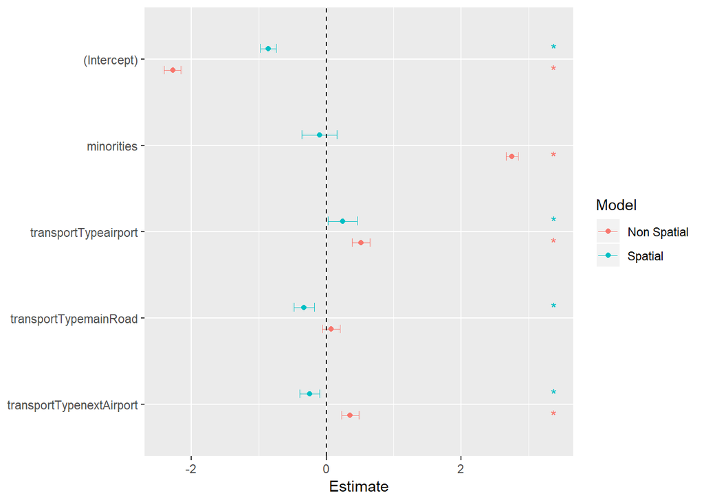

# REFERENCES

[1] Data from The New York Times, based on reports from state and local health agencies. https://www.nytimes.com/interactive/2020/us/coronavirus-us-cases.html.

[2] Center for International Earth Science Information Network - CIESIN - Columbia University, United Nations Food and Agriculture Programme - FAO, and Centro Internacional de Agricultura Tropical - CIAT. 2005. Gridded Population of the World, Version 4 (GPWv4.11): Population Count Grid. Palisades, NY: NASA Socioeconomic Data and Applications Center (SEDAC). http://dx.doi.org/10.7927/H4639MPP. Accessed 21 03 2020.

[3] ACS County-to-County Migration Flows 2013-2017. https://www.census.gov/topics/population/migration.html

[4] CDC SVI 2018 Documentation, 1/31/2020. https://svi.cdc.gov/Documents/Data/2018_SVI_Data/SVI2018Documentation.pdf

[5] Moraga, Paula. (2019). Geospatial Health Data: Modeling and Visualization with R-INLA and Shiny. Chapman & Hall/CRC Biostatistics Series.

[6] Spatial and spatio-temporal models with R-INLA. M Blangiardo, M Cameletti, G Baio, H Rue. Spatial and spatio-temporal epidemiology 4, 33-49.

[7] Flanagan, Barry E.; Gregory, Edward W.; Hallisey, Elaine J.; Heitgerd, Janet L.; and Lewis, Brian (2011) “A Social Vulnerability Index for Disaster Management,” Journal of Homeland Security and Emergency Management: Vol. 8: Iss. 1, Article 3. DOI: 10.2202/1547-7355.1792

[8] Jung I (2009). “A Generalized Linear Models Approach to Spatial Scan Statistics for Covariate Adjustment.” Statistics in Medicine, 28(7), 1131–1143. doi:10.1002/sim.3535.

[9] Zhang T, Lin G (2009). “Spatial Scan Statistics in Loglinear Models.” Computational Statistics & Data Analysis, 53(8), 2851–2858. doi:10.1016/j.csda.2008.09.016.

[10] Kulldorff M (1997). “A Spatial Scan Statistic.” Communications in Statistics – Theory and Methods, 26(6), 1481–1496. doi:10.1080/03610929708831995.

[11] Waller LA, Gotway CA (2004). Applied Spatial Statistics for Public Health Data. John Wiley & Sons. doi:10.1002/0471662682.

[12] Gómez-Rubio V, Moraga P, Molitor J (2018). “Fast Bayesian Classification for Disease Mapping and the Detection of Disease Clusters.” In M Cameletti, F Finazzi (eds.), Quantitative Methods in Environmental and Climate Research, pp. 1–27. Springer-Verlag. doi: 10.1007/978-3-030-01584-8_1.

[13] Gómez-Rubio, V., Moraga, P., Molitor, J., & Rowlingson, B. (2019). DClusterm: Model-Based Detection of Disease Clusters. Journal of Statistical Software, 90(14), 1 - 26. doi:http://dx.doi.org/10.18637/jss.v090.i14.